# MTH6139 Time Series

# 4. Prophet model predictions

## 4.1 Modelling and Forecasting

```r
# Training
model <- prophet::prophet(SnP_500_df)
```

```
## Disabling daily seasonality. Run prophet with daily.seasonality=TRUE to override this.
```

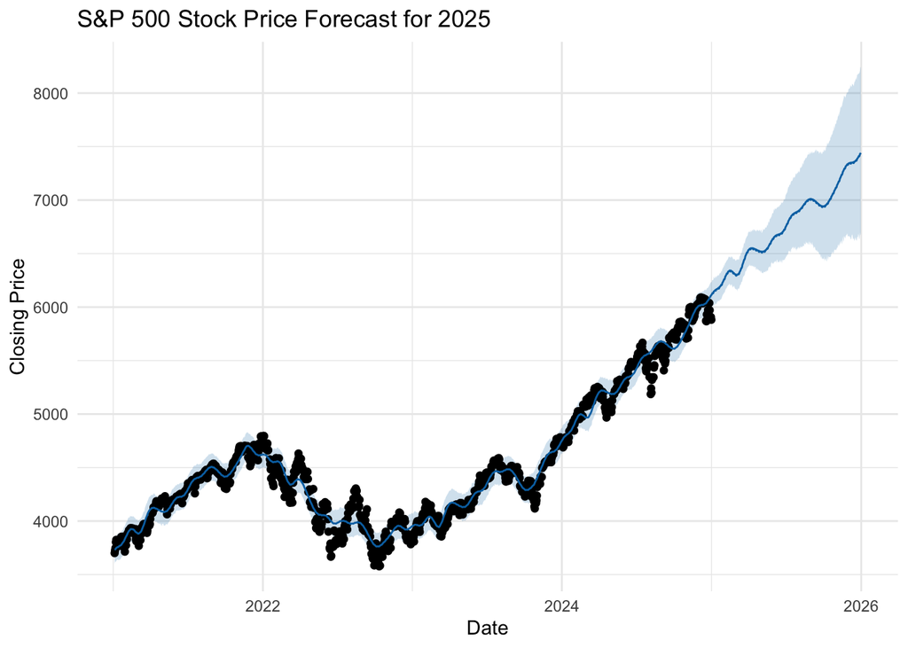

```r
# Generate data for the next year
Future <- prophet::make_future_dataframe(model, periods = 365, freq = "day")
Forecast <- predict(model, Future)

# Plotting forecast results
plot(model, Forecast) +
    ggplot2::ggtitle("S&P 500 Stock Price Forecast for 2025") +
    ggplot2::labs(x = "Date", y = "Closing Price") +
    ggplot2::theme_minimal()
```

The black dots represent actual S&P 500 historical prices. The blue line represents the predicted trend for 2025. The shaded blue area is the confidence interval.

The model predicts a upward movement in the SnP_500 in 2025. The S&P 500 is forecasted to move to around 7500 points by the end of 2025. The forecast shows wider confidence intervals as we move further into the future.

## 4.2 Plot forecast components (trend & seasonality)

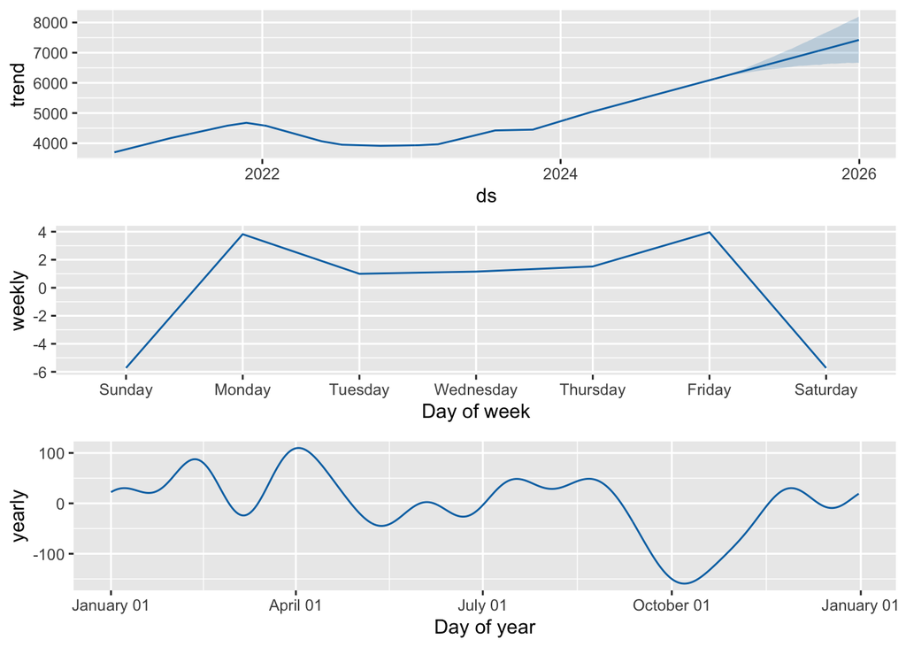

```r
prophet::prophet_plot_components(model, Forecast)
```

The trend component shows a steady upward movement in the S&P 500, but there is a drop during 2022. The long-term trend is upwards. The blue shaded region represents the uncertainty interval, which indicates higher prediction uncertainty over time.